# chương 2 trich tu bo hoang oppa

**Câu 7:** Một lượng khí xác định được biểu diễn thông qua nhóm thông số trạng thái là

**A.** khối lượng, áp suất và nhiệt độ.

**B.** áp suất, nhiệt độ và khối lượng riêng.

**C.** # áp suất, nhiệt độ và thể tích.

**D.** nhiệt độ, thể tích và khối lượng.

**Câu 2 (Đ/S). (dành cho các bạn siêng)** Một mol khí lí tưởng thực hiện chu trình biến đổi được biểu diễn bằng đồ thị như hình vẽ bên dưới. Biết p<sub>1</sub> = 8,31.10<sup>5</sup> Pa; T<sub>1</sub> = 300 K; p<sub>2</sub> = 13,85.10<sup>5</sup> Pa.  
- Giai đoạn (1) sang (2): đồ thị là một phần của nhánh Parabol có đỉnh tại gốc tọa độ O (phương trình Parabol này có dạng T = aV<sup>2</sup> với a là hằng số tính theo đơn vị K/m<sup>6</sup>);  
- Giai đoạn (2) sang (3): Đồ thị là một đoạn thẳng có đường kéo dài vuông góc với trục OV;  
- Giai đoạn (3) về (1): Đồ thị là một đoạn thẳng kéo dài đi qua gốc tọa độ O.

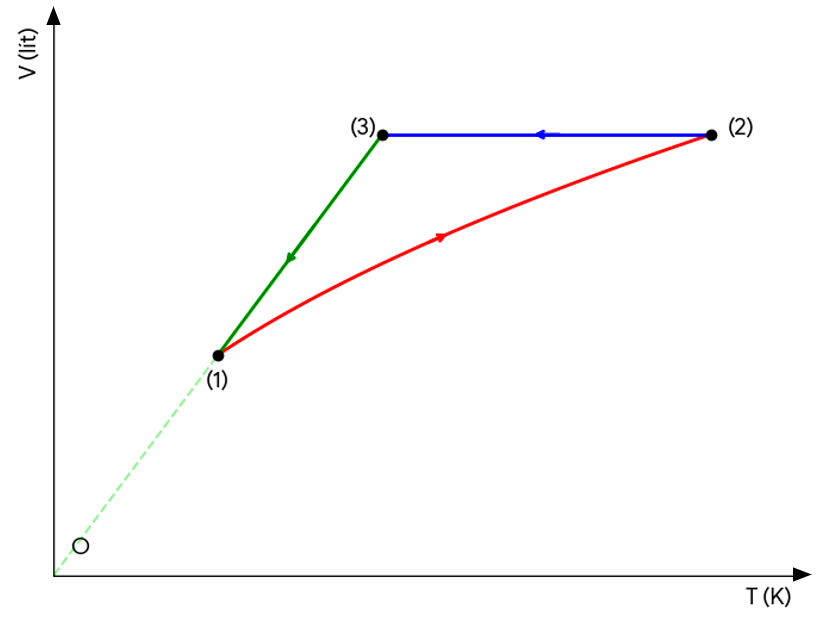

**a)** Đường 2 – 3 biểu diễn quá trình đẳng nhiệt.

**b) #** Đường 3 – 1 biểu diễn quá trình đẳng áp.

**c)** Giá trị của a là 10<sup>8</sup>.

**d) #** Nhiệt độ T<sub>2</sub> xấp xỉ bằng 833,3 K.

[HD]  
a) SAI *Trong hệ tọa độ V – T, đồ thị từ (2) sang (3) là đoạn thẳng có đường kéo dài vuông góc với trục OV nên quá trình này là quá trình đẳng tích.*  
**b) ĐÚNG** *Trong hệ tọa độ V – T, đồ thị từ (3) về (1) là đoạn thẳng có đường kéo dài đi qua gốc tọa độ O nên quá trình này là quá trình đẳng áp.*  
**c) SAI** *Phương trình clapeyron của khối khí tại trạng thái (1):* $p_{1}.V_{1} = n.R.T_{1} \Longrightarrow V_{1} = \frac{n.R.T_{1}}{p_{1}} = \frac{1 \bullet 8,31 \bullet 300}{{8,31.10}^{5}} = {3.10}^{- 3}\ m^{3} = 3\ lít;$ *Giá trị của a:* $T_{1} = a.V_{1}^{2} \Longrightarrow a = \frac{T_{1}}{V_{1}^{2}} = \frac{300}{\left( {3.10}^{- 3} \right)^{2}} \approx {33,3.10}^{6}\ K/m^{6}.$  
**d) ĐÚNG** *Từ trạng thái (1) đến (2):* $\frac{T}{V^{2}} = a = hằng\ số$*. Vì vậy:* $\frac{T_{1}}{V_{1}^{2}} = \frac{T_{2}}{V_{2}^{2}} \Longrightarrow V_{2} = V_{1}.\sqrt{\frac{T_{2}}{T_{1}}} = {3.10}^{- 3} \bullet \sqrt{\frac{T_{2}}{300}};$ *Nhiệt độ tại trạng thái (2):* $p_{2}.V_{2} = n.R.T_{2} \Longleftrightarrow {13,85.10}^{5} \bullet {3.10}^{- 3} \bullet \sqrt{\frac{T_{2}}{300}} = 1 \bullet 8,31 \bullet T_{2} \Longrightarrow T_{2} \approx 833,33\ K.$

**Câu 2.** Xét một bình kín chứa một hỗn hợp khí gồm 20% số phân tử là Oxygen và 80% số phân tử là Nitrogen. Biết bình đang có nhiệt độ bằng nhiệt độ phòng. Hãy chọn phát biểu đúng.

**A.** Khối lượng của một phân tử Oxygen bằng với khối lượng một phân tử Nitrogen.

**B.** Áp suất khí tác dụng lên thành bình bằng với áp suất riêng phần của Oxygen và bằng với áp suất riêng phần của Nitrogen.

**C.** Giá trị căn bậc hai của trung bình bình phương tốc độ của các phân tử Oxygen bằng với giá trị đó của các phân tử Nitrogen.

**D. #** Động năng chuyển động nhiệt trung bình của các phân tử Oxygen bằng với động năng chuyển động nhiệt trung bình của các phân tử Nitrogen.

**[HD]**  
Vì khối khí có nhiệt độ đồng nhất nên động năng chuyển động nhiệt trung bình của hai phần khí là bằng nhau.  
Vì khối lượng phân tử Oxygen khác khối lượng phân tử Nitrogen nên tốc độ căn quân phương của hai lượng khí này khác nhau. $v_{\text{cqp}} = \sqrt{\frac{3kT}{m}},\quad m_{O_{2}} \neq m_{N_{2}}\quad \Rightarrow \quad v_{\text{cqp }\text{O}_{2}} \neq v_{\text{cqp }\text{N}_{2}}.$

**Câu 6.** Cho một khối khí trong xi lanh có pít tông có thể dịch chuyển được. Ban đầu, khối khí ở trạng thái (1) với áp suất $p_{1}$ và thể tích $V_{1}.$ Khi đẩy pít tông nhanh để nén khí lại, sau đó giữ cố định pít tông và đợi đến khi nhiệt độ trở về bằng với nhiệt độ ban đầu, lúc này khí ở trạng thái (2) với áp suất $p_{2}$ và thể tích $V_{2}.$ Hãy chọn phát biểu đúng.

**A.** Quá trình biến đổi trạng thái từ (1) đến (2) là quá trình đẳng nhiệt.

**B**. # Trạng thái (1) và trạng thái (2) là hai trạng thái đẳng nhiệt.

**C.** Quá trình biến đổi trạng thái từ (1) đến (2) là quá trình đẳng áp.

**D.** Trạng thái (1) và trạng thái (2) là hai trạng thái đẳng áp.

**Câu 10.** Một khối khí lý tưởng có nhiệt độ 27

[figure not shown]

động năng chuyển động tịnh tiến trung bình của các phân tử khí là bao nhiêu?

**A.** $\text{3,11} \times 10^{- 21}\ \text{J.}$

**B**. $\text{6,21} \times 10^{- 23}\ \text{J.}$

**C.** $\text{3,11} \times 10^{- 212}\ \text{J.}$

**D.** # $\text{6,21} \times 10^{- 21}\ \text{J.}$

**[HD]** Động năng chuyển động tịnh tiến trung bình $\overline{W_{d}} = \frac{3}{2}kT = \frac{3}{2} \times \text{1,38} \times 10^{- 23} \times (27 + 273) = \text{6,21} \times 10^{- 21}\ \text{J.}$

**Câu 14.** Theo thuyết động học phân tử, đối với chất rắn, các phân tử chỉ dao động quanh các vị trí cân bằng xác định, giữa các phân tử có khoảng cách. Xét một khối sắt tinh khiết ở thể rắn. Khoảng giữa các nguyên tử sắt là

**A.** # chân không.

**B**. sắt.

**C.** không khí.

**D.** các phân tử tạp chất.

**Câu 5.** Trong quá trình đẳng áp của một lượng khí xác định, thể tích của khí

**A.** # tỉ lệ thuận với nhiệt độ tuyệt đối.

**B.** tỉ lệ nghịch với áp suất.

**C.** tỉ lệ nghịch với nhiệt độ tuyệt đối.

**D.** tỉ lệ thuận với áp suất.

**Câu 6.** Một nhóm học sinh tiến hành thí nghiệm kiểm chứng định luật Boyle được bố trí như hình vẽ bên dưới. Kết quả thí nghiệm được nhóm học sinh ghi lại như bảng bên dưới. Lấy 1 Bar = 10<sup>5</sup> Pa.

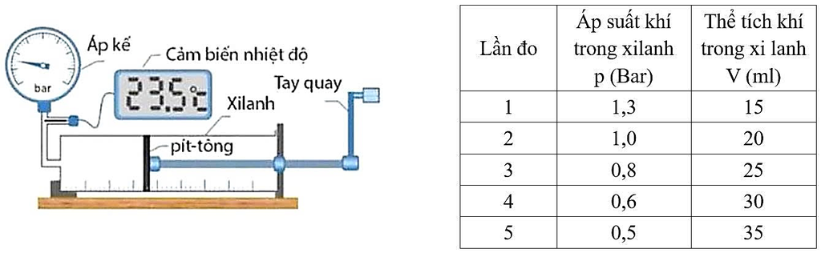

Trong quá trình làm thí nghiệm, số chỉ của cảm biến nhiệt độ gần như không đổi. Quá trình biến đổi trạng thái của khối khí trong xi lanh là quá trình

**A.** dãn nở đẳng áp.

**B.** nén đẳng áp.

**C.** # dãn nở đẳng nhiệt.

**D.** nén đẳng nhiệt.

**Câu 7.** Một nhóm học sinh tiến hành thí nghiệm kiểm chứng định luật Boyle được bố trí như hình vẽ bên dưới. Kết quả thí nghiệm được nhóm học sinh ghi lại như bảng bên dưới. Lấy 1 Bar = 10<sup>5</sup> Pa.

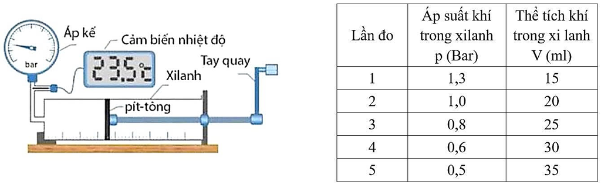

Căn cứ vào các số liệu thí nghiệm, số mol của lượng khí chứa trong xi lanh có giá trị xấp xỉ bằng

**A.** 9,7.10<sup>−3</sup> mol.

**B.** 0,77 mol.

**C.** 7,7.10<sup>−3</sup> mol.

**D.** # 7,7.10<sup>−4</sup> mol.

**Câu 8.** Xét một khối khí lí tưởng có thể tích V, áp suất p, gồm N phân tử, mỗi phân tử có khối lượng $m_{1}$. Công thức nào sau đây đúng khi biểu diễn mối quan hệ giữa áp suất của khối khí tác dụng lên thành bình và động năng tịnh tiến trung bình $\overline{E_{đ}}$ của các phân tử khí?

**A.** $p = \frac{1}{3}\frac{N}{V}\overline{E_{đ}}.$

**B.** $p = \frac{2}{3}\frac{N}{V}\overline{E_{đ}}.$

**C.** $p = \frac{2}{3}N\overline{E_{đ}}.$

**D.** $p = \frac{1}{6}N\overline{E_{đ}}.$

**[HD]**  
*Ta có:* $p = \frac{1}{3}\mu m_{1}\overline{v^{2}} = \frac{1}{3}.\frac{N}{V}m_{1}\overline{v^{2}}$ *và* $\overline{E_{đ}} = \frac{1}{2}m_{1}\overline{v^{2}}$ *🡪 Suy ra:* $p = \frac{2}{3}.\frac{N}{V}.\overline{E_{đ}}$*.*

**Câu 9.** Định luật mô tả mối quan hệ giữa thể tích và nhiệt độ tuyệt đối của một khối khí lý tưởng khi áp suất của nó không đổi được gọi là

**A.** định luật Boyle.

**B.** # định luật Charles.

**C.** định luật Faraday.

**D.** định luật Dalton.

**Câu 11.** Khi một khối khí lý tưởng xác định được tăng thể tích lên hai lần trong điều kiện nhiệt độ không đổi thì

**A.** áp suất tăng hai lần.

**B.** nội năng tăng hai lần.

**C.** # áp suất giảm hai lần.

**D.** nội năng giảm hai lần.

[HD] Trong điều kiện nhiệt độ không đổi, áp suất biến đổi tỉ lệ nghịch với thể tích. Vì vậy, khi thể tích tăng hai lần thì áp suất giảm hai lần.

**Câu 7 (Đ/S):** Một khối khí lí tưởng thực hiện quá trình nén đẳng áp, chuyển từ trạng thái (1) sang trạng thái (2). Biết rằng thể tích của khối khí giảm 2 lần và nhiệt độ của khối khí ở trạng thái (1) là 327 °C.

a) # Nhiệt độ của khối khí ở trạng thái (2) bằng 300K

**b)** Đồ thị phù hợp với quá trình biến đổi trạng thái của khối khí nói trên

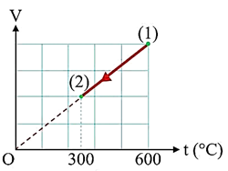

c) Định luật Charles được áp dụng cho quá trình này.

d) Trong quá trình biến đổi, khi nhiệt độ tăng thì thể tích tăng tỉ lệ thuận

**[HD]**  
*a) Đúng, Ta có:* $\frac{V_{1}}{T_{1}} = \frac{V_{2}}{T_{2}}$ *⇔* $\frac{2.V_{2}}{327 + 273} = \frac{V_{2}}{T_{2}}$ *⇒* $T_{2} = 300$ *K.*  
b) Sai, *Đồ thị 2 không phù hợp với quá trình biến đổi trạng thái của khối khí nói trên vì* $T_{1} = 600$ *K và* $T_{2} = 300$ K. Quan trọng hơn là tên trục nằm ngang phải là trục T (K) mới đúng  
d) sai vì phải nói nhiệt độ tuyệt đối mới đúng.

**Câu 8.** Khi giá trị trung bình của các bình phương tốc độ chuyển động nhiệt của các phân tử khí tăng gấp 4 lần thì nhiệt độ tuyệt đối của khối khí sẽ

**A.** giảm 16 lần.

**B.** tăng 2 lần.

**C.** # tăng 4 lần.

**D.** tăng 16 lần.

**Câu 9:** Xét một khối khí lí tưởng xác định, định luật Charles cho biết hệ thức liên hệ giữa

**A.** áp suất và nhiệt độ tuyệt đối khi thể tích không đổi.

**B.** # thể tích và nhiệt độ tuyệt đối khi áp suất không đổi.

**C.** thể tích và áp suất khi nhiệt độ không đổi.

**D.** thể tích, áp suất và nhiệt độ tuyệt đối của khí.

**[HD]** *Định luật Charles (quá trình đẳng áp) cho biết hệ thức liên hệ giữa thể tích và nhiệt độ khi áp suất không đổi.*

**Câu 11:** Theo mô hình động học phân tử, ở thể lỏng, các phân tử

**A.** dao động quanh vị trí cân bằng cố định.

**B.** chuyển động hỗn loạn.

**C.** # dao động quanh vị trí cân bằng không cố định.

**D.** đứng yên.

**Câu 12:** Trong hệ tọa độ (p, T), đường đẳng tích là

**A.** đường thẳng song song với trục Op.

**B.** đường thẳng song song với trục OT.

**C.** đường hyperbol.

**D.** # đường thẳng nếu kéo dài thì đi qua gốc tọa độ.

**[HD]** *Trong hệ tọa độ (p, T), đường đẳng tích là đường thẳng có đường kéo dài đi qua gốc tọa độ.*

**Câu 17:** Một khối khí lí tưởng có khối lượng 10,5g, chứa trong bình dung tích 3 lít có áp suất 300 kPa và nhiệt độ 18<sup>o</sup>C . Khối lượng mol của khí này gần nhất với giá trị nào sau đây?

**A.** 32 g/mol.

**B.** 44 g/mol.

**C.** 2 g/mol.

**D.** # 28 g/mol.

**[HD]**  
*Phương trình của khối khí lí tưởng:* $pV = \frac{m}{M}RT\ \Longrightarrow M = \frac{mRT}{pV} = \frac{10,5 \bullet 8,31 \bullet (18 + 273)}{{300.10}^{3} \bullet {3.10}^{- 3}} \approx 28\ g/mol.$

**Câu 18.** Hai bình kín A và B chứa cùng một loại khí có mật độ phân tử khí tương ứng là µ<sub>1</sub> và µ<sub>2</sub> = 0,5µ<sub>1</sub>. Nếu nhiệt độ tuyệt đối của bình B gấp 4 lần bình A thì áp suất của bình A và B lúc đó lần lượt là p<sub>1</sub> và p<sub>2</sub>. Kết luận nào sau đây đúng?

**A.** p<sub>1</sub> = p<sub>2</sub>.

**B.** # p<sub>1</sub> = 0,5p<sub>2</sub>.

**C.** p<sub>1</sub> = 2p<sub>2</sub>.

**D.** p<sub>1</sub> = 4p<sub>2</sub>.

**[HD]** *Ta có* $p = \mu kT \Longrightarrow \frac{p_{1}}{p_{2}} = \frac{\mu_{1}T_{1}}{\mu_{2}T_{2}} = \frac{\mu_{1}T_{1}}{\frac{1}{2}\mu_{1}.4T_{1}} = \frac{1}{2} \Longrightarrow p_{1} = \frac{p_{2}}{2} = 0,5p_{2}.$